# Predicting Outpatient Visits and Self-Reported Physical Limitation

## 0.1 Preliminaries

```r
library(Ecdat);
library(tidyverse)
```

# 1 Task 1: Data Source

My data are from “DoctorContacts” within the Ecdat package. The data are available through R, but can also be downloaded through [this link](https://raw.githubusercontent.com/vincentarelbundock/Rdatasets/master/csv/Ecdat/DoctorContacts.csv).

# 2 Task 2: Load and Tidy the Data

```r
visits <- read.csv("DoctorContacts.csv") %>% tbl_df

set.seed(33)
visits_new <- sample_n(visits, 1000)
```

The data set has no missing values, but does have 20,186 observations. Therefore, I created a random sample of 1000 (setting a seed at 33) and saved this new sample of data as visits_new.

# 3 Task 3: Listing of My Tibble

```r
visits_new
```

```
# A tibble: 1,000 x 16
       X   mdu    lc idp     lpi  fmde physlim ndisease health  linc  lfam
   <int> <int> <dbl> <lgl> <dbl> <dbl> <lgl>      <dbl> <fct>  <dbl> <dbl>
 1  9002     3  3.93 F      6.60  7.29 T          20.7  fair    8.13  0
 2  7967    14  4.56 T      6.11  6.16 F           3.40 excel~  9.47  1.79
 3  9764     3  3.93 F      6.91  7.60 F           9.97 excel~  9.37  1.39
 4 18546     0  4.56 F      6.91  6.96 F           6.90 excel~  9.52  1.10
 5 17032     0  4.56 T      6.11  6.16 F          10.3  good    5.37  1.95
 6 10441     1  0    F      6.19  0    F           3.40 excel~  9.73  1.61
 7  8822     4  0    F      3.84  0    T           6.90 excel~  9.39  1.79
 8  6926     5  0    F      6.25  0    F          11.8  excel~  8.76  1.61
 9   314     1  0    T      5.84  0    F           4.30 excel~  8.42  0
10  2381     4  0    T      5.14  0    F          17.4  fair    8.34  0
# ... with 990 more rows, and 5 more variables: educdec <dbl>, age <dbl>,
#   sex <fct>, child <lgl>, black <lgl>
```

```r
glimpse(visits_new)
```

```
Observations: 1,000
Variables: 16
$ X        <int> 9002, 7967, 9764, 18546, 17032, 10441, 8822, 6926, 31...
$ mdu      <int> 3, 14, 3, 0, 0, 1, 4, 5, 1, 4, 0, 2, 3, 1, 2, 1, 2, 1...
$ lc       <dbl> 3.931826, 4.564348, 3.931826, 4.564348, 4.564348, 0.0...
$ idp      <lgl> FALSE, TRUE, FALSE, FALSE, TRUE, FALSE, FALSE, FALSE,...
$ lpi      <dbl> 6.599871, 6.109248, 6.907755, 6.907755, 6.109248, 6.1...
$ fmde     <dbl> 7.293018, 6.160541, 7.600903, 6.959049, 6.160541, 0.0...
$ physlim  <lgl> TRUE, FALSE, FALSE, FALSE, FALSE, FALSE, TRUE, FALSE,...
$ ndisease <dbl> 20.700000, 3.400000, 9.967326, 6.900000, 10.300000, 3...
$ health   <fct> fair, excellent, excellent, excellent, good, excellen...
$ linc     <dbl> 8.129408, 9.467853, 9.370708, 9.517982, 5.368392, 9.7...
$ lfam     <dbl> 0.0000000, 1.7917590, 1.3862940, 1.0986120, 1.9459100...
$ educdec  <dbl> 10, 11, 14, 13, 10, 12, 9, 12, 16, 12, 14, 12, 12, 11...
$ age      <dbl> 48.906910, 22.409310, 9.147160, 45.763860, 43.578370,...
$ sex      <fct> female, male, male, female, male, male, male, male, f...
$ child    <lgl> FALSE, FALSE, TRUE, FALSE, FALSE, TRUE, TRUE, TRUE, F...
$ black    <lgl> FALSE, FALSE, FALSE, FALSE, TRUE, FALSE, FALSE, FALSE...
```

My tibble has 1000 subjects and 16 variables, 8 of which I will include in analyses.

# 4 Task 4: Code Book

| Variable | Type | Details |
| --- | --- | --- |
| `X` | character | Identification code (0 to 20186; 1000 randomly selected) |
| `mdu` | quantitative | Number of outpatient visits to a medical doctor |
| `physlim` | binary | Physical limitation (TRUE, FALSE) |
| `ndisease` | quantitative | Number of chronic diseases |
| `health` | multi-categorical | Self–rated health (EXCELLENT, GOOD, FAIR, POOR) |
| `age` | quantitative | Exact age in years |
| `sex` | binary | Sex (MALE, FEMALE) |
| `educdec` | quantitative | Years of schooling of household head |

# 5 Task 5: My Subjects

Subjects were participants in the RAND Health Insurance Experiment. These data describe a sample of 20186 individual members of families living in select regions of Ohio, Washington, Massachusetts, and South Carolina that were free of disability in 1974.

# 6 Task 6: My Variables

All responses were recorded in person by investigators. The number of outpatient visits (range: 0-65) and physical limitation will be the examined outcomes in these analyses. The number of outpatient doctor visits represents the number for that year. Physical limitation was self-reported. Sources: [1](http://ase.tufts.edu/economics/papers/partha_deb.pdf), [2](http://www.centroportici.unina.it/centro/Cameron&Trivedi.pdf), [3](http://ww2.amstat.org/sections/SRMS/Proceedings/y1975/A%20Finite%20Selection%20Model%20for%20Experimental%20Design%20of%20the%20Health%20Insurance%20Study.pdf), [4](https://www.rand.org/content/dam/rand/pubs/reports/2006/R3055.pdf), [5](https://www.jstor.org/stable/3765469?seq=1#page_scan_tab_contents)

# 7 Task 7: My Planned Linear Regression Model

`mdu`, or the number of outpatient visits to the doctor, will be my quantitative outcome. My candidate predictors are age, sex, years of schooling, self-reported health, and number of chronic diseases.

# 8 Task 8: My Planned Logistic Regression Model

# 9 Task 9: Affirmation

My data include 1000 observations, which is the the maximum upper row limit. It also includes 16 variables, 8 of which (including `X`, or ID number) will be used in my regression analyses. I have one quantitative outcome, number of outpatient visits, which ranges from 0-65 in my sample of 1000, and one binary categorical outcome, physical limitation, which is coded as “TRUE” or “FALSE”. I have five candidate predictors, which will be used in both regression analyses. Three of these are quantitative (age, ranging from 0.16 to 63.18; years of schooling, ranging from 0 to 24; and number of chronic diseases, ranging from 0 to 39), one is binary categorical (sex), and one is multi-categorical (self-reported health, which was coded as “excellent”, “good”, “fair”, or “poor”).

I am certain that it is completely appropriate for these data to be shared with anyone, without any conditions. There are no concerns about privacy or security.

# 10 Task 10 Analysis: Linear Regression

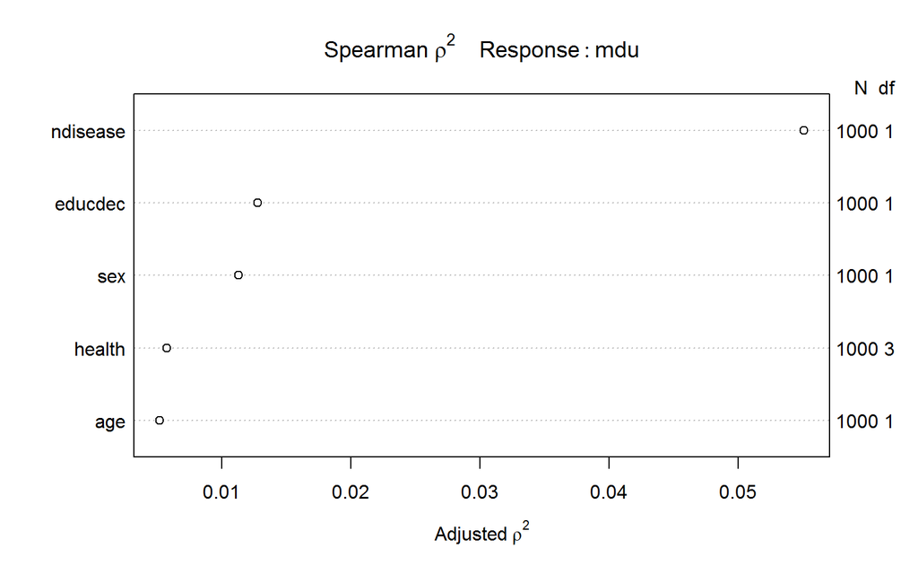

```r
plot(Hmisc::spearman2(mdu ~ age + sex + educdec + health + ndisease, data = visits_new))
```

```r
m1 <- lm(mdu ~ age + sex + educdec + health + ndisease, data = visits_new)
m2 <- lm(mdu ~ age + sex + poly(educdec, 2) + health + rms::rcs(ndisease, 3), data = visits_new)
m1
```

```
Call:
lm(formula = mdu ~ age + sex + educdec + health + ndisease, data = visits_new)

Coefficients:
(Intercept)          age      sexmale      educdec   healthfair
  -0.004424     0.017775    -0.610393     0.125015     0.323758
 healthgood   healthpoor     ndisease
  -0.127710     0.861882     0.127855
```

```r
m2
```

```
Call:
lm(formula = mdu ~ age + sex + poly(educdec, 2) + health + rms::rcs(ndisease,
    3), data = visits_new)

Coefficients:
                   (Intercept)                             age
                       1.18466                         0.02099
                       sexmale               poly(educdec, 2)1
                      -0.60894                        11.41802
             poly(educdec, 2)2                      healthfair
                      -2.40497                         0.34136
                    healthgood                      healthpoor
                      -0.12488                         0.87294
 rms::rcs(ndisease, 3)ndisease  rms::rcs(ndisease, 3)ndisease'
                       0.16361                        -0.05027
```

```r
broom::glance(m1)
```

```
   r.squared adj.r.squared    sigma statistic      p.value df    logLik
1 0.04836592    0.04165076 4.961727  7.202497 1.980413e-08  8 -3016.676
       AIC      BIC deviance df.residual
1 6051.353 6095.523 24421.79         992
```

```r
broom::glance(m2)
```

```
  r.squared adj.r.squared    sigma statistic      p.value df    logLik
1 0.0490374    0.04039228 4.964984  5.672267 1.099469e-07 10 -3016.323
       AIC      BIC deviance df.residual
1 6054.647 6108.632 24404.56         990
```

```r
anova(m1)
```

```
Analysis of Variance Table

Response: mdu
           Df  Sum Sq Mean Sq F value    Pr(>F)
age         1   207.5  207.45  8.4266  0.003780 **
sex         1   195.5  195.51  7.9415  0.004927 **
educdec     1   137.8  137.81  5.5980  0.018173 *
health      3    56.0   18.68  0.7588  0.517332
ndisease    1   644.4  644.40 26.1750 3.743e-07 ***
Residuals 992 24421.8   24.62
---
Signif. codes:  0 '***' 0.001 '**' 0.01 '*' 0.05 '.' 0.1 ' ' 1
```

```r
anova(m2)
```

```
Analysis of Variance Table

Response: mdu
                       Df  Sum Sq Mean Sq F value   Pr(>F)
age                     1   207.5  207.45  8.4156 0.003803 **
sex                     1   195.5  195.51  7.9311 0.004956 **
poly(educdec, 2)        2   138.7   69.34  2.8128 0.060519 .
health                  3    57.5   19.17  0.7777 0.506526
rms::rcs(ndisease, 3)   2   659.3  329.65 13.3726 1.86e-06 ***
Residuals             990 24404.6   24.65
---
Signif. codes:  0 '***' 0.001 '**' 0.01 '*' 0.05 '.' 0.1 ' ' 1
```

```r
with(visits_new,
     step(lm(mdu ~ 1),
          scope = ~ age + sex + educdec + health + ndisease),
     direction = "forward")
```

```
Start:  AIC=3247.05
mdu ~ 1

           Df Sum of Sq   RSS    AIC
+ ndisease  1    934.02 24729 3212.0
+ age       1    207.45 25456 3240.9
+ sex       1    195.33 25468 3241.4
+ educdec   1    118.92 25544 3244.4
<none>                  25663 3247.1
+ health    3     77.46 25586 3250.0

Step:  AIC=3211.98
mdu ~ ndisease

           Df Sum of Sq   RSS    AIC
+ educdec   1    102.82 24626 3209.8
+ age       1     84.61 24644 3210.5
+ sex       1     77.06 24652 3210.9
<none>                  24729 3212.0
+ health    3     21.07 24708 3217.1
- ndisease  1    934.02 25663 3247.1

Step:  AIC=3209.81
mdu ~ ndisease + educdec

           Df Sum of Sq   RSS    AIC
+ age       1     91.61 24535 3208.1
+ sex       1     82.89 24543 3208.4
<none>                  24626 3209.8
- educdec   1    102.82 24729 3212.0
+ health    3     40.92 24585 3214.1
- ndisease  1    917.92 25544 3244.4

Step:  AIC=3208.08
mdu ~ ndisease + educdec + age

           Df Sum of Sq   RSS    AIC
+ sex       1     88.86 24446 3206.5
<none>                  24535 3208.1
- age       1     91.61 24626 3209.8
- educdec   1    109.82 24644 3210.5
+ health    3     23.23 24511 3213.1
- ndisease  1    791.95 25327 3237.9

Step:  AIC=3206.45
mdu ~ ndisease + educdec + age + sex

           Df Sum of Sq   RSS    AIC
<none>                  24446 3206.5
- sex       1     88.86 24535 3208.1
- age       1     97.59 24543 3208.4
- educdec   1    116.29 24562 3209.2
+ health    3     23.90 24422 3211.5
- ndisease  1    676.53 25122 3231.8
```

```
Call:
lm(formula = mdu ~ ndisease + educdec + age + sex)

Coefficients:
(Intercept)     ndisease      educdec          age      sexmale
    0.02557      0.12895      0.11782      0.01895     -0.60721
```

```r
with(visits_new,
     step(lm(mdu ~ age + sex + educdec + health + ndisease),
     direction = "backward"))
```

```
Start:  AIC=3211.48
mdu ~ age + sex + educdec + health + ndisease

           Df Sum of Sq   RSS    AIC
- health    3     23.90 24446 3206.5
<none>                  24422 3211.5
- age       1     79.96 24502 3212.7
- sex       1     89.54 24511 3213.1
- educdec   1    123.44 24545 3214.5
- ndisease  1    644.40 25066 3235.5

Step:  AIC=3206.45
mdu ~ age + sex + educdec + ndisease

           Df Sum of Sq   RSS    AIC
<none>                  24446 3206.5
- sex       1     88.86 24535 3208.1
- age       1     97.59 24543 3208.4
- educdec   1    116.29 24562 3209.2
- ndisease  1    676.53 25122 3231.8
```

```
Call:
lm(formula = mdu ~ age + sex + educdec + ndisease)

Coefficients:
(Intercept)          age      sexmale      educdec     ndisease
    0.02557      0.01895     -0.60721      0.11782      0.12895
```

```r
predictors <- with(visits_new, cbind(age, sex, educdec, health, ndisease))
m3 <- leaps::regsubsets(predictors, y = visits_new$mdu,
                        nvmax = 5, nbest = 1)
m3_summ <- summary(m3)
m3_summ
```

```
Subset selection object
5 Variables  (and intercept)
         Forced in Forced out
age          FALSE      FALSE
sex          FALSE      FALSE
educdec      FALSE      FALSE
health       FALSE      FALSE
ndisease     FALSE      FALSE
1 subsets of each size up to 5
Selection Algorithm: exhaustive
         age sex educdec health ndisease
1  ( 1 ) " " " " " "     " "    "*"
2  ( 1 ) " " " " "*"     " "    "*"
3  ( 1 ) "*" " " "*"     " "    "*"
4  ( 1 ) "*" "*" "*"     " "    "*"
5  ( 1 ) "*" "*" "*"     "*"    "*"
```

```r
m3_summ$which
```

```
  (Intercept)   age   sex educdec health ndisease
1        TRUE FALSE FALSE   FALSE  FALSE     TRUE
2        TRUE FALSE FALSE    TRUE  FALSE     TRUE
3        TRUE  TRUE FALSE    TRUE  FALSE     TRUE
4        TRUE  TRUE  TRUE    TRUE  FALSE     TRUE
5        TRUE  TRUE  TRUE    TRUE   TRUE     TRUE
```

```r
m3_summ$outmat
```

```
         age sex educdec health ndisease
1  ( 1 ) " " " " " "     " "    "*"
2  ( 1 ) " " " " "*"     " "    "*"
3  ( 1 ) "*" " " "*"     " "    "*"
4  ( 1 ) "*" "*" "*"     " "    "*"
5  ( 1 ) "*" "*" "*"     "*"    "*"
```

```r
data_frame(k = 2:6, RSS = m3_summ$rss)
```

```
# A tibble: 5 x 2
      k   RSS
  <int> <dbl>
1     2 24729
2     3 24626
3     4 24535
4     5 24446
5     6 24445
```

```r
m3_summ$aic.c <- 1000*log(m3_summ$rss / 1000) + 2*(2:6) + (2 * (2:6) * ((2:6) +1) / (1000 - (2:6) - 1))
round(m3_summ$aic.c,2)
```

```
[1] 3211.99 3209.83 3208.12 3206.51 3208.50
```

```r
best_models <- data_frame(
  k = 2:6,
  r2 = m3_summ$rsq,
  adjr2 = m3_summ$adjr2,
  aic.c = m3_summ$aic.c,
  cp = m3_summ$cp,
  bic = m3_summ$bic
)
best_models_1 <-cbind(best_models, m3_summ$which)
best_models_1
```

```
  k         r2      adjr2    aic.c       cp        bic (Intercept)   age
1 2 0.03639569 0.03543015 3211.988 9.562620 -23.259021        TRUE FALSE
2 3 0.04040205 0.03847708 3209.834 7.381810 -20.517615        TRUE FALSE
3 4 0.04397188 0.04109227 3208.123 5.656539 -17.336927        TRUE  TRUE
4 5 0.04743445 0.04360504 3206.514 4.043192 -14.057581        TRUE  TRUE
5 6 0.04747584 0.04268447 3208.495 6.000000  -7.193277        TRUE  TRUE
    sex educdec health ndisease
1 FALSE   FALSE  FALSE     TRUE
2 FALSE    TRUE  FALSE     TRUE
3 FALSE    TRUE  FALSE     TRUE
4  TRUE    TRUE  FALSE     TRUE
5  TRUE    TRUE   TRUE     TRUE
```

```r
extractAIC(lm(mdu ~ ndisease, data = visits_new))
```

```
[1]    2.000 3211.976
```

```r
extractAIC(lm(mdu ~ ndisease + educdec, data = visits_new))
```

```
[1]    3.00 3209.81
```

```r
extractAIC(lm(mdu ~ ndisease + educdec + age, data = visits_new))
```

```
[1]    4.000 3208.082
```

```r
extractAIC(lm(mdu ~ ndisease + educdec + age + sex, data = visits_new))
```

```
[1]    5.000 3206.454
```

```r
extractAIC(lm(mdu ~ ndisease + educdec + age + sex + health, data = visits_new))
```

```
[1]    8.000 3211.476
```

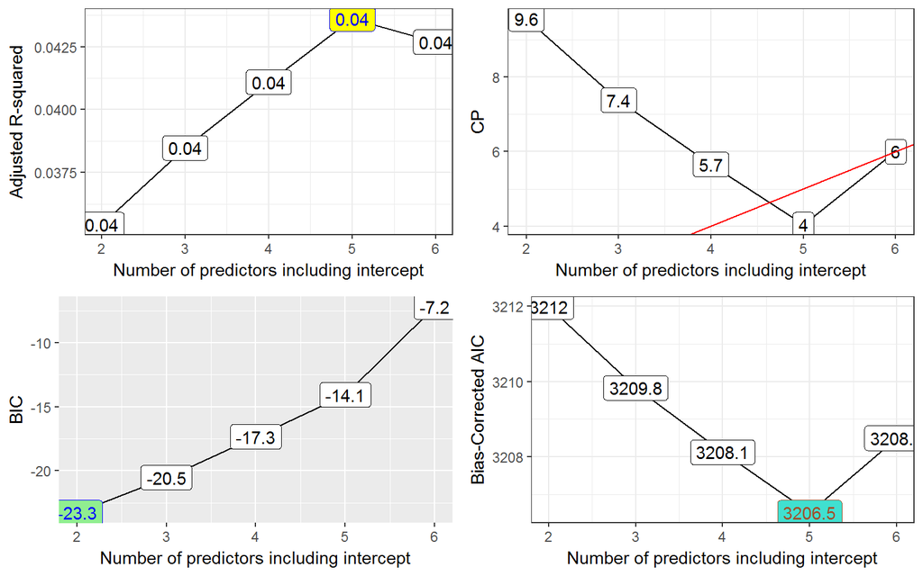

```r
plot1 <- ggplot(best_models_1, aes(x = k, y = adjr2,
                                   label = round(adjr2,2))) +
  geom_line() +
  geom_label() +
  geom_label(data = subset(best_models_1,
                           adjr2 == max(adjr2)),
             aes(x = k, y = adjr2, label = round(adjr2,2)),
             fill = "yellow", col = "blue") +
  theme_bw() +
  scale_x_continuous(breaks = 2:6) +
  labs(x = "Number of predictors including intercept",
                                  y = "Adjusted R-squared")

plot2 <- ggplot(best_models_1, aes(x = k, y = cp,
                                   label = round(cp,1))) +
  geom_line() +
  geom_label() +
  geom_abline(intercept = 0, slope = 1, col = "red") +
             theme_bw() +
               scale_x_continuous(breaks = 2:6) +
                                    labs(x = "Number of predictors including intercept",
                                  y = "CP")

plot3 <- ggplot(best_models_1, aes(x = k, y = bic,
                                   label = round(bic,1))) +
  geom_line() +
  geom_label() +
  geom_label(data = subset(best_models_1,
                           bic==min(bic)),
             aes(x = k, y = bic), fill = "lightgreen", col = "blue") +
               scale_x_continuous(breaks = 2:6) +
                                    labs(x = "Number of predictors including intercept",
                                  y = "BIC")

plot4 <- ggplot(best_models_1, aes(x = k, y = aic.c,
                                   label = round(aic.c,1))) +
  geom_line() +
  geom_label() +
  geom_label(data = subset(best_models_1,
                           aic.c==min(aic.c)),
             aes(x = k, y = aic.c), fill = "turquoise", col = "sienna") +
  theme_bw() +
  scale_x_continuous(breaks = 2:6) +
  labs(x = "Number of predictors including intercept",
                                  y = "Bias-Corrected AIC")

gridExtra::grid.arrange(plot1, plot2, plot3, plot4, nrow = 2)
```

```r
m4 <- lm(mdu ~ ndisease + educdec + age + sex, data = visits_new)
m4
```

```
Call:
lm(formula = mdu ~ ndisease + educdec + age + sex, data = visits_new)

Coefficients:
(Intercept)     ndisease      educdec          age      sexmale
    0.02557      0.12895      0.11782      0.01895     -0.60721
```

```r
m5 <- rms::ols(mdu ~ ndisease + educdec + age + sex, data = visits_new, x = TRUE, y = TRUE)
m5
```

```
Linear Regression Model

 rms::ols(formula = mdu ~ ndisease + educdec + age + sex, data = visits_new,
     x = TRUE, y = TRUE)

                Model Likelihood     Discrimination
                   Ratio Test           Indexes
 Obs    1000    LR chi2     48.60    R2       0.047
 sigma4.9567    d.f.            4    R2 adj   0.044
 d.f.    995    Pr(> chi2) 0.0000    g        1.203

 Residuals

     Min      1Q  Median      3Q     Max
 -6.2507 -2.4552 -1.2679  0.8714 62.0772


           Coef    S.E.   t     Pr(>|t|)
 Intercept  0.0256 0.7710  0.03 0.9735
 ndisease   0.1290 0.0246  5.25 <0.0001
 educdec    0.1178 0.0542  2.18 0.0298
 age        0.0190 0.0095  1.99 0.0465
 sex=male  -0.6072 0.3193 -1.90 0.0575
```

```r
d <- rms::datadist(visits_new)
options(datadist = "d")
anova(m5)
```

```
                Analysis of Variance          Response: mdu

 Factor     d.f. Partial SS  MS        F     P
 ndisease     1    676.53413 676.53413 27.54 <.0001
 educdec      1    116.28996 116.28996  4.73 0.0298
 age          1     97.58653  97.58653  3.97 0.0465
 sex          1     88.86009  88.86009  3.62 0.0575
 REGRESSION   4   1217.31052 304.32763 12.39 <.0001
 ERROR      995  24445.69348  24.56854
```

```r
summary(m5)
```

```
             Effects              Response : mdu

 Factor            Low    High   Diff.   Effect   S.E.    Lower 0.95
 ndisease           6.900 13.732  6.8319  0.88100 0.16789  0.5515400
 educdec           11.000 13.000  2.0000  0.23564 0.10831  0.0230990
 age               11.561 38.837 27.2760  0.51689 0.25936  0.0079466
 sex - male:female  1.000  2.000      NA -0.60721 0.31928 -1.2337000
 Upper 0.95
 1.210500
 0.448190
 1.025800
 0.019334
```

```r
plot(summary(m5))
summary(m5, conf.type = c('simultaneous'))
```

```
             Effects              Response : mdu

 Factor            Low    High   Diff.   Effect   S.E.    Lower 0.95
 ndisease           6.900 13.732  6.8319  0.88100 0.16789  0.479750
 educdec           11.000 13.000  2.0000  0.23564 0.10831 -0.023216
 age               11.561 38.837 27.2760  0.51689 0.25936 -0.102960
 sex - male:female  1.000  2.000      NA -0.60721 0.31928 -1.233700
 Upper 0.95
 1.282200
 0.494500
 1.136700
 0.019334
```

[figure not shown]

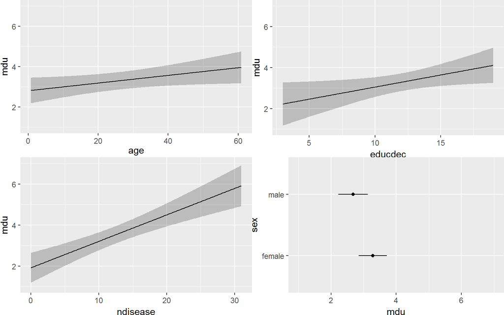

```r
ggplot(rms::Predict(m5))
```

```r
set.seed(33); rms::validate(m5, method = "boot", B = 50)
```

```
          index.orig training    test optimism index.corrected  n
R-square      0.0474   0.0579  0.0428   0.0151          0.0323 50
MSE          24.4457  23.8126 24.5650  -0.7523         25.1980 50
g             1.2030   1.2834  1.1750   0.1084          1.0946 50
Intercept     0.0000   0.0000  0.1943  -0.1943          0.1943 50
Slope         1.0000   1.0000  0.9361   0.0639          0.9361 50
```

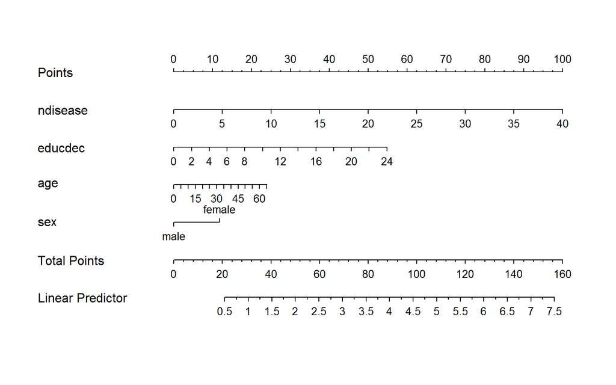

```r
plot(rms::nomogram(m5))
```